# Práctica 8. BLAST

Autor/a

Laura Monleón Vicente

Fecha de publicación

10 de mayo de 2026

# 1 Introducción

BLAST (*Basic Local Alignment Search Tool*) permite realizar alineamientos locales entre una secuencia problema, denominada *query*, y una base de datos de secuencias. Cada secuencia de la base de datos que se alinea con la query se denomina *subject*. La utilidad principal de BLAST es detectar semejanza local entre secuencias, lo que permite inferir homología, asignar funciones putativas, comparar proteomas o detectar el posible origen taxonómico de lecturas no mapeadas.

En esta práctica se aplican tres usos diferentes de BLAST:

1. Identificación aproximada de ortólogos mediante mejores hits recíprocos (*reciprocal best hits*).
2. Detección de homologías lejanas mediante PSI-BLAST.
3. Identificación taxonómica de lecturas no mapeadas mediante BLASTN remoto.

**Nota**

Los programas `blastp`, `blastn`, `psiblast`, `blastdbcmd`, `makeblastdb` y `segmasker` son ejecutables externos. Por tanto, se ejecutan en chunks de Bash, no en la consola de R.

# 2 Preparación

Necesitamos tener instalado el paquete `ncbi-blast+`. En sistemas Linux basados en Debian o Ubuntu puede instalarse con:

```bash
sudo apt update
sudo apt install ncbi-blast+
```

La ayuda completa de cada programa puede consultarse desde la terminal. Por ejemplo:

```bash
blastp -help | head
```

```
USAGE
  blastp [-h] [-help] [-import_search_strategy filename]
    [-export_search_strategy filename] [-task task_name] [-db database_name]
    [-dbsize num_letters] [-gilist filename] [-seqidlist filename]
    [-negative_gilist filename] [-negative_seqidlist filename]
    [-taxids taxids] [-negative_taxids taxids] [-taxidlist filename]
    [-negative_taxidlist filename] [-ipglist filename]
    [-negative_ipglist filename] [-entrez_query entrez_query]
    [-db_soft_mask filtering_algorithm] [-db_hard_mask filtering_algorithm]
    [-subject subject_input_file] [-subject_loc range] [-query input_file]
```

Para el ejercicio 3 también se utilizan los programas `datasets` y `dataformat` de NCBI. En mi entorno los ejecutables están disponibles en `~/.local/bin/`, por lo que en los chunks se usa esa ruta para evitar problemas de `PATH` durante el renderizado desde RStudio.

Además, se utiliza el paquete de R `Biostrings` para leer secuencias FASTA comprimidas.

```r
if (!requireNamespace("Biostrings", quietly = TRUE)) {
  stop("El paquete Biostrings no está instalado. Instálalo con BiocManager::install('Biostrings').")
}

library(Biostrings)
```

# 3 Objetivos

Los objetivos de esta práctica son:

- Identificar proteínas posiblemente ortólogas entre dos especies mediante BLASTP.
- Aplicar PSI-BLAST para detectar homologías lejanas entre proteínas de una misma superfamilia.
- Determinar el origen probable de lecturas no mapeadas mediante BLASTN remoto y análisis taxonómico.
- Integrar herramientas externas de Bash con análisis e interpretación en R.
- Documentar resultados de forma reproducible mediante Quarto.

# 4 Datos

## 4.1 Datos del primer ejercicio

En el primer ejercicio se utilizan los proteomas de dos bacterias endosimbiontes de insectos:

- *Buchnera aphidicola*.
- *Blochmannia ocreatus*.

Ambas bacterias presentan genomas reducidos, lo que facilita las búsquedas y permite trabajar con bases de datos locales relativamente pequeñas. Los proteomas pueden descargarse desde UniProt y se asume que están guardados en la carpeta `../../data/` con los nombres:

- `buchnera.fa`
- `blochmannia.fa`

Estos archivos contienen secuencias proteicas en formato FASTA. Cada entrada representa una proteína, con una cabecera iniciada por `>` y una secuencia de aminoácidos asociada.

```bash
ls -lh ../../data/buchnera.fa ../../data/blochmannia.fa
head -5 ../../data/buchnera.fa
head -5 ../../data/blochmannia.fa
```

```
-rw-r--r-- 1 laumonv4 usuarios^del^dominio 268K may  7 10:38 ../../data/blochmannia.fa
-rw-r--r-- 1 laumonv4 usuarios^del^dominio 270K may  7 10:37 ../../data/buchnera.fa
>sp|P57290|AKH_BUCAI Bifunctional aspartokinase/homoserine dehydrogenase OS=Buchnera aphidicola subsp. Acyrthosiphon pisum (strain APS) OX=107806 GN=thrA PE=3 SV=1
MKLLKFGGTSLANAEKFLSVSSIIEENTQTDQIAVVLSAPAKITNYLVKIIENTIKNNQI
LETVHLAENIFMQLINNFLNIQSNFPHKEIEKIIKKEFNELKNIIQGILLLKQCPDNIRA
IIISRGEILSVFIMKSILQSKNYNVTIINPVKNLVAIGDNYLDSTVDISESKKNIQNMNI
NQSNIILMAGFIAGNKDKKLVVLGRNGSDYSAAVLAACLDANCCEIWTDVDGVFTSDPRK
>tr|A0ABY4SVZ2|A0ABY4SVZ2_9ENTR Siroheme synthase OS=Candidatus Blochmannia ocreatus OX=251538 GN=cysG PE=3 SV=1
MKYLPLFIDLKNKPVLVIGGGSVALRKIQMLQRVGAMIKVIAHTICPELKKLLLKKNINW
IGKKFTPFMLNKVILVIIATNDAKLNTLIYNNANKYHILVNTVDDQSKCSCIFPAIIDRN
PILIGISSCGTAPMLARILREKFELLLPQTLGYIAKFASLWRNTVKKHIINTVHRRRFWE
KVFYDDHIVPLITRNRFKEAKKKFFSTLLNIKHNNSFKTGHVTLVGAGPGDIGLLTIKGL
```

## 4.2 Datos del segundo ejercicio

Para el segundo ejercicio se necesita la base de datos SwissProt preparada para BLAST. Debe estar descargada y descomprimida en `../../data/`. Se puede obtener con:

```bash
cd ../../data
update_blastdb --decompress swissprot
```

Si `update_blastdb` no funcionara, se puede descargar manualmente:

```bash
cd ../../data
wget https://ftp.ncbi.nlm.nih.gov/blast/db/swissprot.tar.gz.md5
wget https://ftp.ncbi.nlm.nih.gov/blast/db/swissprot.tar.gz
md5sum -c swissprot.tar.gz.md5
tar -xzvf swissprot.tar.gz
rm swissprot.tar.gz swissprot.tar.gz.md5
```

Comprobamos que la base de datos local existe:

```bash
ls -lh ../../data/swissprot.p* | head
```

```
-rw-r--r-- 1 laumonv4 usuarios^del^dominio  24M abr 14 12:02 ../../data/swissprot.pdb
-rw-r--r-- 1 laumonv4 usuarios^del^dominio 121M abr 14 12:02 ../../data/swissprot.phr
-rw-r--r-- 1 laumonv4 usuarios^del^dominio 3,8M abr 14 12:02 ../../data/swissprot.pin
-rw-r--r-- 1 laumonv4 usuarios^del^dominio  624 abr 14 12:02 ../../data/swissprot.pjs
-rw-r--r-- 1 laumonv4 usuarios^del^dominio 1,9M abr 14 12:02 ../../data/swissprot.pog
-rw-r--r-- 1 laumonv4 usuarios^del^dominio 8,7M abr 14 12:02 ../../data/swissprot.pos
-rw-r--r-- 1 laumonv4 usuarios^del^dominio 6,0M abr 14 12:02 ../../data/swissprot.pot
-rw-r--r-- 1 laumonv4 usuarios^del^dominio 3,8M abr 14 12:02 ../../data/swissprot.ppd
-rw-r--r-- 1 laumonv4 usuarios^del^dominio  15K abr 14 12:02 ../../data/swissprot.ppi
-rw-r--r-- 1 laumonv4 usuarios^del^dominio 178M abr 14 12:02 ../../data/swissprot.psq
```

## 4.3 Datos del tercer ejercicio

El archivo `../../data/contaminacion.fa.gz` contiene lecturas procedentes de un experimento de secuenciación del insecto *Aphis aurantii* con Ion Torrent. Son lecturas que no pudieron mapearse al genoma de referencia del insecto, por lo que podrían corresponder a regiones ausentes en el ensamblaje de referencia o a ADN de otros organismos asociados a la muestra.

```bash
ls -lh ../../data/contaminacion.fa.gz
```

```
-rw-r--r-- 1 laumonv4 usuarios^del^dominio 2,7M may  7 12:09 ../../data/contaminacion.fa.gz
```

# 5 Ejercicio 1. Identificación aproximada de ortólogos

Una estrategia habitual para identificar genes ortólogos es comprobar si dos proteínas son, recíprocamente, el mejor resultado de BLAST una respecto a la otra. Este criterio se conoce como *reciprocal best hits* (RBH). Aunque es un método heurístico, suele proporcionar una aproximación razonable cuando se comparan proteomas relativamente cercanos y se busca una primera identificación de ortología.

## 5.1 Enmascarar e indexar los proteomas

Antes de ejecutar BLASTP, se preparan bases de datos locales para ambos proteomas. Además, se usa `segmasker` para enmascarar regiones de baja complejidad, que podrían producir alineamientos espurios.

```bash
if [ ! -e ../../data/buchnera.phr ]; then
   if [ ! -e ../../data/buchnera_seg.asnb ]; then
      segmasker -in ../../data/buchnera.fa \
                -infmt fasta \
                -parse_seqids \
                -outfmt maskinfo_asn1_bin \
                -out ../../data/buchnera_seg.asnb
   fi

   makeblastdb -in ../../data/buchnera.fa \
               -input_type fasta \
               -dbtype prot \
               -parse_seqids \
               -mask_data ../../data/buchnera_seg.asnb \
               -out ../../data/buchnera \
               -title "Proteoma de Buchnera"
fi
```

```bash
if [ ! -e ../../data/blochmannia.phr ]; then
   if [ ! -e ../../data/blochmannia_seg.asnb ]; then
      segmasker -in ../../data/blochmannia.fa \
                -infmt fasta \
                -parse_seqids \
                -outfmt maskinfo_asn1_bin \
                -out ../../data/blochmannia_seg.asnb
   fi

   makeblastdb -in ../../data/blochmannia.fa \
               -input_type fasta \
               -dbtype prot \
               -parse_seqids \
               -mask_data ../../data/blochmannia_seg.asnb \
               -out ../../data/blochmannia \
               -title "Proteoma de Blochmannia"
fi
```

## 5.2 Realizar las búsquedas de BLASTP

El objetivo es encontrar, para cada proteína de *Buchnera aphidicola*, la proteína de *Blochmannia ocreatus* más parecida, y viceversa.

### 5.2.1 De *Buchnera aphidicola* hacia *Blochmannia ocreatus*

```bash
blastp -query ../../data/buchnera.fa \
       -db ../../data/blochmannia \
       -out buc2blo.txt \
       -outfmt '6 qseqid sseqid qlen slen length evalue bitscore' \
       -evalue 0.001 \
       -max_target_seqs 1
```

### 5.2.2 De *Blochmannia ocreatus* hacia *Buchnera aphidicola*

```bash
blastp -query ../../data/blochmannia.fa \
       -db ../../data/buchnera \
       -out blo2buc.txt \
       -outfmt '6 qseqid sseqid qlen slen length evalue bitscore' \
       -evalue 0.001 \
       -max_target_seqs 1
```

**Nota**

La opción `-outfmt 6` genera una tabla tabulada, más fácil de importar en R. La opción `-max_target_seqs 1` conserva únicamente el mejor hit para cada query.

## 5.3 Comparación de resultados

Importamos las dos tablas en R:

```r
buc2blo <- read.table(
   'buc2blo.txt',
   col.names = c('query', 'subject', 'qlen', 'slen',
                 'length', 'evalue', 'bitscore')
)

blo2buc <- read.table(
   'blo2buc.txt',
   col.names = c('query', 'subject', 'qlen', 'slen',
                 'length', 'evalue', 'bitscore')
)

head(buc2blo)
```

```
                 query                        subject qlen slen length
1  sp|P57290|AKH_BUCAI tr|A0ABY4SUV1|A0ABY4SUV1_9ENTR  816  819    820
2 sp|P57139|GLMU_BUCAI tr|A0ABY4SVX7|A0ABY4SVX7_9ENTR  459  467    443
3 sp|P57244|CARB_BUCAI tr|A0ABY4ST92|A0ABY4ST92_9ENTR 1079 1082   1076
4 sp|P57245|CARA_BUCAI tr|A0ABY4STA7|A0ABY4STA7_9ENTR  387  382    374
5 sp|P57265|FOLC_BUCAI tr|A0ABY4SUG5|A0ABY4SUG5_9ENTR  411  425    414
6 sp|P57266|KPRS_BUCAI tr|A0ABY4SVP1|A0ABY4SVP1_9ENTR  315  320    313
     evalue bitscore
1  0.00e+00      835
2 4.08e-141      407
3  0.00e+00     1443
4 1.32e-156      441
5 5.43e-108      320
6  0.00e+00      530
```

```r
head(blo2buc)
```

```
                           query               subject qlen slen length
1 tr|A0ABY4SVZ2|A0ABY4SVZ2_9ENTR  sp|P57500|CYSG_BUCAI  481  473    459
2 tr|A0ABY4SSB9|A0ABY4SSB9_9ENTR   sp|P57398|SYS_BUCAI  429  427    430
3 tr|A0ABY4SSC6|A0ABY4SSC6_9ENTR  sp|P57397|SERC_BUCAI  364  361    363
4 tr|A0ABY4SSK0|A0ABY4SSK0_9ENTR  sp|P57203|HIS7_BUCAI  359  353    358
5 tr|A0ABY4SSK3|A0ABY4SSK3_9ENTR  sp|P57207|HIS2_BUCAI  228  215    205
6 tr|A0ABY4SSL2|A0ABY4SSL2_9ENTR sp|P57254|NUOCD_BUCAI  595  600    593
     evalue bitscore
1 5.94e-166      472
2 5.84e-161      455
3 2.76e-142      403
4 1.45e-141      400
5  4.00e-66      198
6  0.00e+00      876
```

Para identificar los mejores hits recíprocos, renombramos las dos primeras columnas de manera que las parejas puedan compararse directamente:

```r
buc2blo_rbh <- buc2blo
blo2buc_rbh <- blo2buc

colnames(buc2blo_rbh)[1:2] <- c("buchnera", "blochmannia")
colnames(blo2buc_rbh)[1:2] <- c("blochmannia", "buchnera")

ortologos <- merge(
   buc2blo_rbh[, c("buchnera", "blochmannia")],
   blo2buc_rbh[, c("blochmannia", "buchnera")]
)

head(ortologos)
```

```
              buchnera                    blochmannia
1 sp|O05385|RPOH_BUCAI tr|A0ABY4SYP6|A0ABY4SYP6_9ENTR
2 sp|O31297|EFTU_BUCAI tr|A0ABY4SYX1|A0ABY4SYX1_9ENTR
3 sp|O32464|DNAK_BUCAI tr|A0ABY4SZ14|A0ABY4SZ14_9ENTR
4 sp|O32465|DNAJ_BUCAI tr|A0ABY4SVV9|A0ABY4SVV9_9ENTR
5 sp|O66132|KHSE_BUCAI tr|A0ABY4SW67|A0ABY4SW67_9ENTR
6 sp|P25749|CH10_BUCAI tr|A0ABY4ST55|A0ABY4ST55_9ENTR
```

```r
nrow(ortologos)
```

```
[1] 404
```

Las proteínas incluidas en `ortologos` son candidatas a ortólogas, porque cada una es el mejor resultado BLAST de la otra especie. Las relaciones no recíprocas pueden deberse a duplicaciones génicas, pérdida diferencial de genes, parálogos o diferencias en la anotación de los proteomas.

## 5.4 Representación gráfica de los resultados

Para ganar confianza en los resultados, es útil representar variables que indiquen la calidad y coherencia de los alineamientos:

- `bitscore`: puntuación del alineamiento.
- `evalue`: probabilidad esperada de obtener un alineamiento similar por azar.
- `length`: longitud del alineamiento.
- `qlen` y `slen`: longitudes de query y subject.

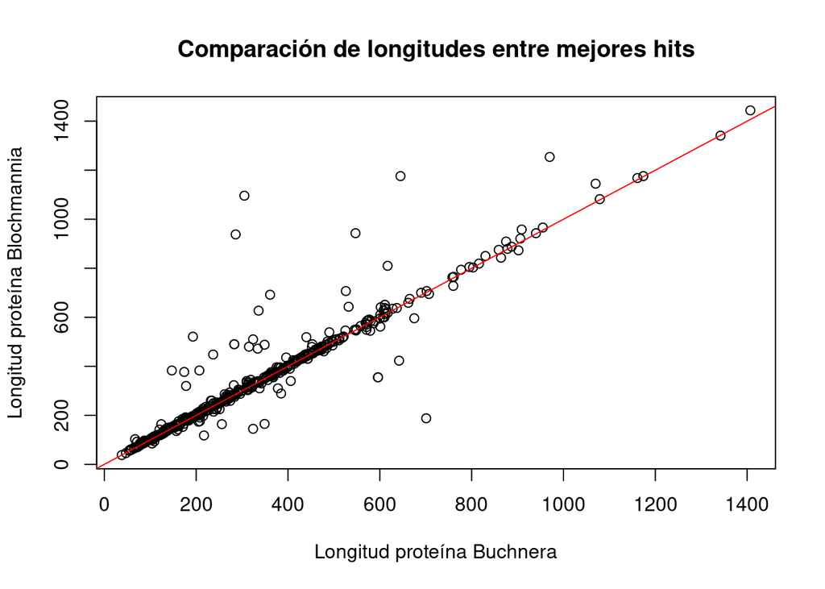

```r
plot(buc2blo$qlen,
     buc2blo$slen,
     xlab = "Longitud proteína Buchnera",
     ylab = "Longitud proteína Blochmannia",
     main = "Comparación de longitudes entre mejores hits")

abline(0, 1, col = "red")
```

En un conjunto de ortólogos esperado, muchas parejas deberían aproximarse a la diagonal, ya que las proteínas ortólogas tienden a conservar tamaños similares. Desviaciones importantes podrían indicar alineamientos parciales, proteínas truncadas o anotaciones diferentes.

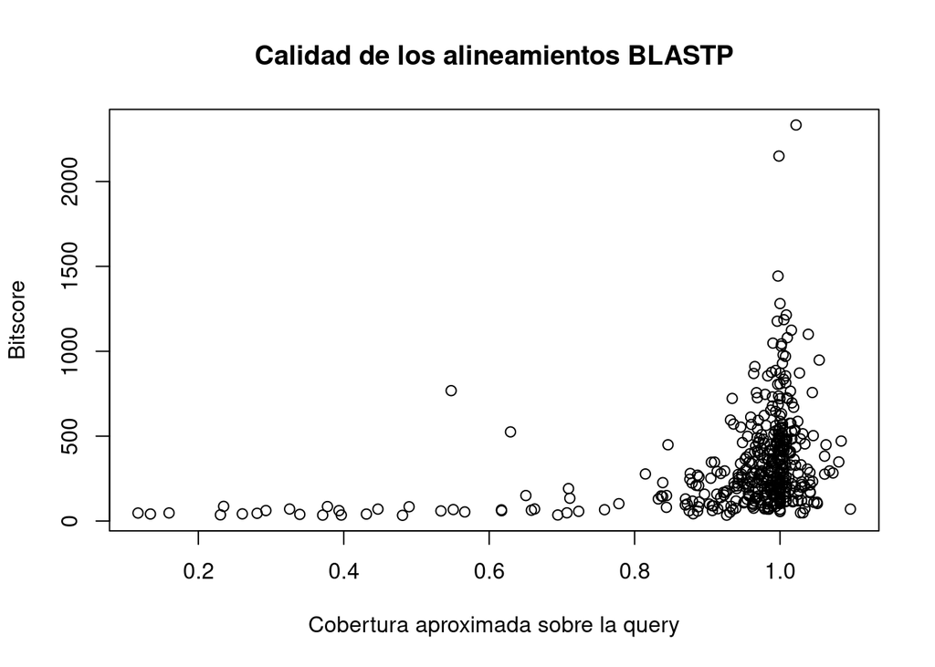

```r
plot(buc2blo$length / buc2blo$qlen,
     buc2blo$bitscore,
     xlab = "Cobertura aproximada sobre la query",
     ylab = "Bitscore",
     main = "Calidad de los alineamientos BLASTP")
```

Los alineamientos con mayor cobertura y mayor `bitscore` son más convincentes como posibles relaciones homólogas. En cambio, alineamientos cortos con puntuaciones bajas deberían interpretarse con cautela.

# 6 Ejercicio 2. PSI-BLAST

PSI-BLAST permite detectar semejanzas más sutiles que BLASTP convencional, especialmente entre miembros alejados de una superfamilia proteica. A diferencia de BLASTP, PSI-BLAST construye de forma iterativa una matriz de puntuación específica de posición (*PSSM*) a partir de las secuencias detectadas en rondas anteriores.

## 6.1 Ejecución inicial con P39615

```bash
blastdbcmd -db ../../data/swissprot \
           -entry P39615 \
           -out P39615.fa

psiblast -db ../../data/swissprot \
         -query P39615.fa \
         -out P39615.blastout.txt \
         -evalue 0.1 \
         -outfmt 7 \
         -inclusion_ethresh 0.001 \
         -num_iterations 7 \
         -matrix BLOSUM62
```

## 6.2 Comparación con otras proteínas

A continuación se repite el análisis con varias proteínas de la lista propuesta. Es importante que el nombre del archivo de salida dependa de la proteína analizada para evitar sobrescribir resultados.

```bash
for proteina in Q9CC91 P39615 B1AJI8 P47343; do
   blastdbcmd -db ../../data/swissprot -entry $proteina -out $proteina.fa

   psiblast -db ../../data/swissprot \
            -query $proteina.fa \
            -out $proteina.blastout.txt \
            -evalue 0.1 \
            -outfmt 7 \
            -inclusion_ethresh 0.01 \
            -num_iterations 7 \
            -matrix BLOSUM45
done
```

[output not shown]

**Nota**

Durante la ejecución de PSI-BLAST pueden aparecer advertencias relacionadas con el ajuste de puntuación basado en la composición de la secuencia. Estas advertencias no impiden el análisis; PSI-BLAST reajusta automáticamente el parámetro a un valor compatible con el uso de PSSM.

Comprobamos que los archivos de salida se han generado:

```bash
ls -lh Q9CC91.blastout.txt P39615.blastout.txt B1AJI8.blastout.txt P47343.blastout.txt
```

```
-rw-r--r-- 1 laumonv4 usuarios^del^dominio  77K may 10 17:22 B1AJI8.blastout.txt
-rw-r--r-- 1 laumonv4 usuarios^del^dominio  57K may 10 17:22 P39615.blastout.txt
-rw-r--r-- 1 laumonv4 usuarios^del^dominio  77K may 10 17:22 P47343.blastout.txt
-rw-r--r-- 1 laumonv4 usuarios^del^dominio 3,7K may 10 17:21 Q9CC91.blastout.txt
```

## 6.3 Interpretación de parámetros

La opción `-evalue` establece el umbral de valor E para mostrar resultados. En este caso, se muestran alineamientos con un valor E igual o inferior a 0.1.

La opción `-inclusion_ethresh`, en cambio, determina qué secuencias se incorporan al perfil PSSM en cada iteración. Por tanto, es un parámetro más delicado, porque afecta directamente a cómo se construye el perfil que se usará en las rondas posteriores.

La diferencia principal es que `-evalue` controla qué resultados se reportan, mientras que `-inclusion_ethresh` controla qué secuencias influyen en la construcción iterativa del perfil.

Para hacer la búsqueda más sensible se puede:

- aumentar el número de iteraciones;
- utilizar una matriz más permisiva, como BLOSUM45;
- relajar ligeramente el umbral de inclusión;
- usar una base de datos más amplia.

Sin embargo, aumentar demasiado la sensibilidad incrementa el riesgo de incorporar falsos positivos al perfil.

# 7 Ejercicio 3. Origen de la contaminación en un archivo FASTQ

El archivo `../../data/contaminacion.fa.gz` contiene 33174 lecturas procedentes de un experimento de secuenciación del insecto *Aphis aurantii* con Ion Torrent. Son lecturas que no pudieron mapearse al genoma de referencia del insecto. Esto puede ocurrir porque el genoma de referencia sea incompleto o porque esas lecturas procedan de otros organismos presentes en la muestra: simbiontes, parásitos, microbiota, presas o restos vegetales.

## 7.1 Selección aleatoria de 20 queries

Para no enviar miles de secuencias a los servidores remotos de NCBI, se toma una muestra aleatoria de 20 lecturas. Para que el resultado sea reproducible, se fija una semilla con `set.seed()` y se guarda la muestra en `muestra.fa`.

```r
set.seed(123)

unmapped <- readDNAStringSet('../../data/contaminacion.fa.gz')
n <- length(unmapped)

n
```

```
[1] 33174
```

```r
muestra <- unmapped[sample(1:n, 20)]
writeXStringSet(muestra, 'muestra.fa')

muestra
```

```
DNAStringSet object of length 20:
     width seq                                              names
 [1]   222 TAATATTTGTCGAATTGTTATTT...AAAAATAACTACTAAATGGTCT SRR13258790.155487
 [2]   211 TACTGTAATGTAGAGGGCTACCA...AGGTTGGTTATGCAGAACACAA SRR13258790.742641
 [3]   329 CATAATGGTTGCCGTCCTCCTAA...TTAAAAGGAAATACTGGAGAAA SRR13258790.737609
 [4]   265 TATTTCAGGTATTAAACTATCAA...TGTTATTTGACAAAGCTCTTTC SRR13258790.150285
 [5]   322 AATAATTTTTTCAGAAATAAAAA...AATAGTAACTGATTTAAGTTTT SRR13258790.306068
 ...   ... ...
[16]   215 TGAAGTCTTGTTTTTGGATCTTT...CTAATTGTAAATATTCTCCTAA SRR13258790.630544
[17]   308 GGATAGCCAGAATCGAAAGGGGA...AATGTGAGTGTCCAGAGAACAC SRR13258790.227308
[18]   331 TATTTATAATTTAACTAAATATA...AGATATACCTAATGTAGGAGAA SRR13258790.491279
[19]   214 CACCTGCTGCATCATCTAACGAA...AACCTAGAGAACAAGCAAAAGT SRR13258790.7306
[20]   280 GCCAACATGTTTATTTTCTAATA...TTTATTTTTAGTTTAACTTGTG SRR13258790.718780
```

**Importante**

El archivo `muestra.fa` debe conservarse en el repositorio, porque procede de una selección aleatoria. Aunque se use `set.seed()`, conservar el archivo facilita la trazabilidad exacta del análisis.